# DA 605 - Assignment 11

Dan Fanelli

## LINEAR REGRESSION IN R

- Your submission should include the final linear fits, and their corresponding significance levels.
- In addition, you should clearly state what you concluded from looking at the fit and their significance levels.

```r
library(knitr)
library(ggplot2)
library(rpart)
```

### Age and Max HR:

**We hear that MaxHR = 220 - Age**

```r
age <- c(18,23,25,35,65,54,34,56,72,19,23,42,18,39,37)
maxHR <- c(202,186,187,180,156,169,174,172,153,199,193,174,198,183,178)
hr_age_formula <- as.formula("maxHR ~ 220 - age")
hr_age_df <- data.frame(age, maxHR)
summary(hr_age_df)
```

```
##       age            maxHR
##  Min.   :18.00   Min.   :153.0
##  1st Qu.:23.00   1st Qu.:173.0
##  Median :35.00   Median :180.0
##  Mean   :37.33   Mean   :180.3
##  3rd Qu.:48.00   3rd Qu.:190.0
##  Max.   :72.00   Max.   :202.0
```

```r
kable(hr_age_df, align = "l")
```

| age | maxHR |
| --- | --- |
| 18 | 202 |
| 23 | 186 |
| 25 | 187 |
| 35 | 180 |
| 65 | 156 |
| 54 | 169 |
| 34 | 174 |
| 56 | 172 |
| 72 | 153 |
| 19 | 199 |
| 23 | 193 |
| 42 | 174 |
| 18 | 198 |
| 39 | 183 |
| 37 | 178 |

Using R’s lm function:

1. Perform regression analysis

```r
hr_age_model <- lm(maxHR ~ age)
summary(hr_age_model)
```

```
##
## Call:
## lm(formula = maxHR ~ age)
##
## Residuals:
##     Min      1Q  Median      3Q     Max
## -8.9258 -2.5383  0.3879  3.1867  6.6242
##
## Coefficients:
##              Estimate Std. Error t value Pr(>|t|)
## (Intercept) 210.04846    2.86694   73.27  < 2e-16 ***
## age          -0.79773    0.06996  -11.40 3.85e-08 ***
## ---
## Signif. codes:  0 '***' 0.001 '**' 0.01 '*' 0.05 '.' 0.1 ' ' 1
##
## Residual standard error: 4.578 on 13 degrees of freedom
## Multiple R-squared:  0.9091, Adjusted R-squared:  0.9021
## F-statistic:   130 on 1 and 13 DF,  p-value: 3.848e-08
```

2. Measure the signicance of the independent variables

```r
summary(hr_age_model)
```

```
##
## Call:
## lm(formula = maxHR ~ age)
##
## Residuals:
##     Min      1Q  Median      3Q     Max
## -8.9258 -2.5383  0.3879  3.1867  6.6242
##
## Coefficients:
##              Estimate Std. Error t value Pr(>|t|)
## (Intercept) 210.04846    2.86694   73.27  < 2e-16 ***
## age          -0.79773    0.06996  -11.40 3.85e-08 ***
## ---
## Signif. codes:  0 '***' 0.001 '**' 0.01 '*' 0.05 '.' 0.1 ' ' 1
##
## Residual standard error: 4.578 on 13 degrees of freedom
## Multiple R-squared:  0.9091, Adjusted R-squared:  0.9021
## F-statistic:   130 on 1 and 13 DF,  p-value: 3.848e-08
```

*The independent variable ‘age’ has a *** next to it, so its significance level is basically 0.*

3. What is the resulting equation?

```r
HR = 210.04846 + (-0.79773)*age
```

4. Is the effect of Age on Max HR significant?

5. What is the signicance level?

*The significant level is *** which is basically zero.*

6. Please also plot the fitted relationship between Max HR and Age.

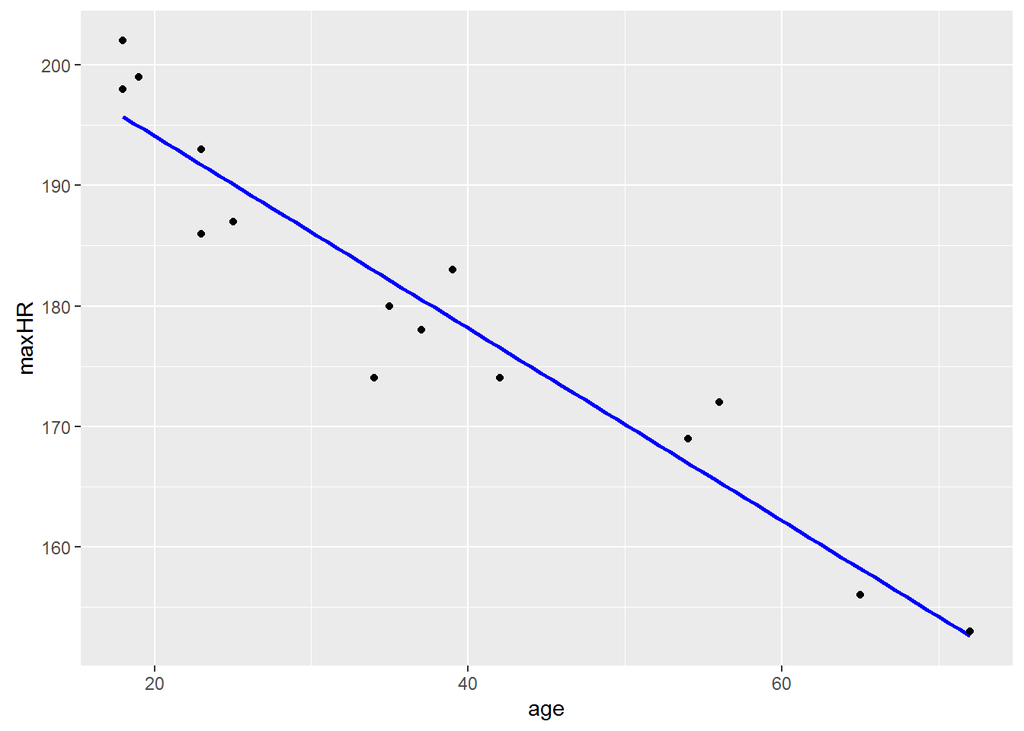

```r
ggplot(data = hr_age_df, aes(x = age, y = maxHR)) + geom_smooth(method = "lm", se=FALSE, color="blue", formula = y ~ x) + geom_point()
```

### Auto Data:

Using the Auto data set from Assignment 5 (also attached here) perform a Linear Regression analysis using mpg as the dependent variable and the other 4 (displacement, horsepower, weight, acceleration) as independent variables.

```r
mpg_df <- read.table("auto-mpg.data", sep="")
names(mpg_df) <- c("mpg", "cylinders", "displacement", "horsepower", "weight", "acceleration", "model_year", "origin", "car_name")

mpg_df <- mpg_df[,c("mpg","displacement","horsepower","weight","acceleration")]
mpg_df <- subset(mpg_df, displacement != '?' && horsepower != '?' && weight != '?' && acceleration != '?')

kable(head(mpg_df, n=10), align = "l")
```

| mpg | displacement | horsepower | weight | acceleration |
| --- | --- | --- | --- | --- |
| 18 | 307 | 130.0 | 3504 | 12.0 |
| 15 | 350 | 165.0 | 3693 | 11.5 |
| 18 | 318 | 150.0 | 3436 | 11.0 |
| 16 | 304 | 150.0 | 3433 | 12.0 |
| 17 | 302 | 140.0 | 3449 | 10.5 |
| 15 | 429 | 198.0 | 4341 | 10.0 |
| 14 | 454 | 220.0 | 4354 | 9.0 |
| 14 | 440 | 215.0 | 4312 | 8.5 |
| 14 | 455 | 225.0 | 4425 | 10.0 |
| 15 | 390 | 190.0 | 3850 | 8.5 |

1. What is the final linear regression fit equation?
2. Which of the 4 independent variables have a significant impact on mpg?
3. What are their corresponding significance levels?
4. What are the standard errors on each of the coeficients?

```r
# it was showing horsepower as categorical, so giving strange results
mpg_df <- transform(mpg_df, horsepower = as.numeric(horsepower))

head(mpg_df)
```

```
##   mpg displacement horsepower weight acceleration
## 1  18          307         17   3504         12.0
## 2  15          350         35   3693         11.5
## 3  18          318         29   3436         11.0
## 4  16          304         29   3433         12.0
## 5  17          302         24   3449         10.5
## 6  15          429         42   4341         10.0
```

```r
summary(mpg_df)
```

```
##       mpg         displacement     horsepower        weight
##  Min.   : 9.00   Min.   : 68.0   Min.   : 1.00   Min.   :1613
##  1st Qu.:17.50   1st Qu.:104.2   1st Qu.:26.00   1st Qu.:2224
##  Median :23.00   Median :148.5   Median :60.50   Median :2804
##  Mean   :23.51   Mean   :193.4   Mean   :51.39   Mean   :2970
##  3rd Qu.:29.00   3rd Qu.:262.0   3rd Qu.:79.00   3rd Qu.:3608
##  Max.   :46.60   Max.   :455.0   Max.   :94.00   Max.   :5140
##   acceleration
##  Min.   : 8.00
##  1st Qu.:13.82
##  Median :15.50
##  Mean   :15.57
##  3rd Qu.:17.18
##  Max.   :24.80
```

```r
mpg_model <- lm(mpg ~ mpg_df$displacement + mpg_df$horsepower + mpg_df$weight + mpg_df$acceleration, data = mpg_df)

summary(mpg_model)
```

```
##
## Call:
## lm(formula = mpg ~ mpg_df$displacement + mpg_df$horsepower +
##     mpg_df$weight + mpg_df$acceleration, data = mpg_df)
##
## Residuals:
##      Min       1Q   Median       3Q      Max
## -11.8331  -2.8735  -0.3164   2.4449  16.2079
##
## Coefficients:
##                       Estimate Std. Error t value Pr(>|t|)
## (Intercept)         40.8838025  1.9966258  20.476  < 2e-16 ***
## mpg_df$displacement -0.0106291  0.0065254  -1.629   0.1041
## mpg_df$horsepower    0.0047774  0.0082597   0.578   0.5633
## mpg_df$weight       -0.0061405  0.0007449  -8.243 2.54e-15 ***
## mpg_df$acceleration  0.1722165  0.0976340   1.764   0.0785 .
## ---
## Signif. codes:  0 '***' 0.001 '**' 0.01 '*' 0.05 '.' 0.1 ' ' 1
##
## Residual standard error: 4.298 on 393 degrees of freedom
## Multiple R-squared:  0.7006, Adjusted R-squared:  0.6976
## F-statistic:   230 on 4 and 393 DF,  p-value: < 2.2e-16
```

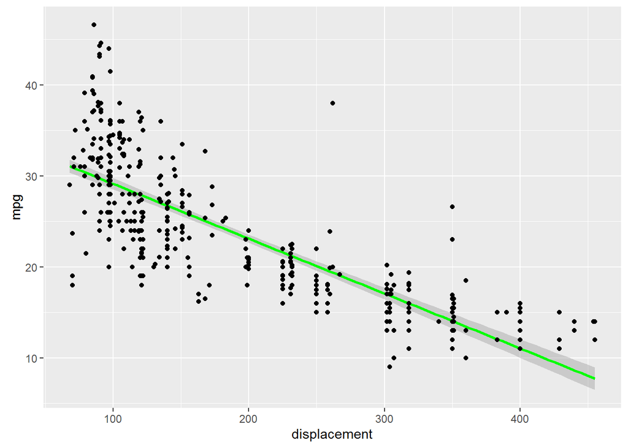

```r
###########
ggplot(data = mpg_df, aes(y = mpg, x = displacement)) +     geom_smooth(method = "lm", color="green", formula = y ~ x) + geom_point()
```

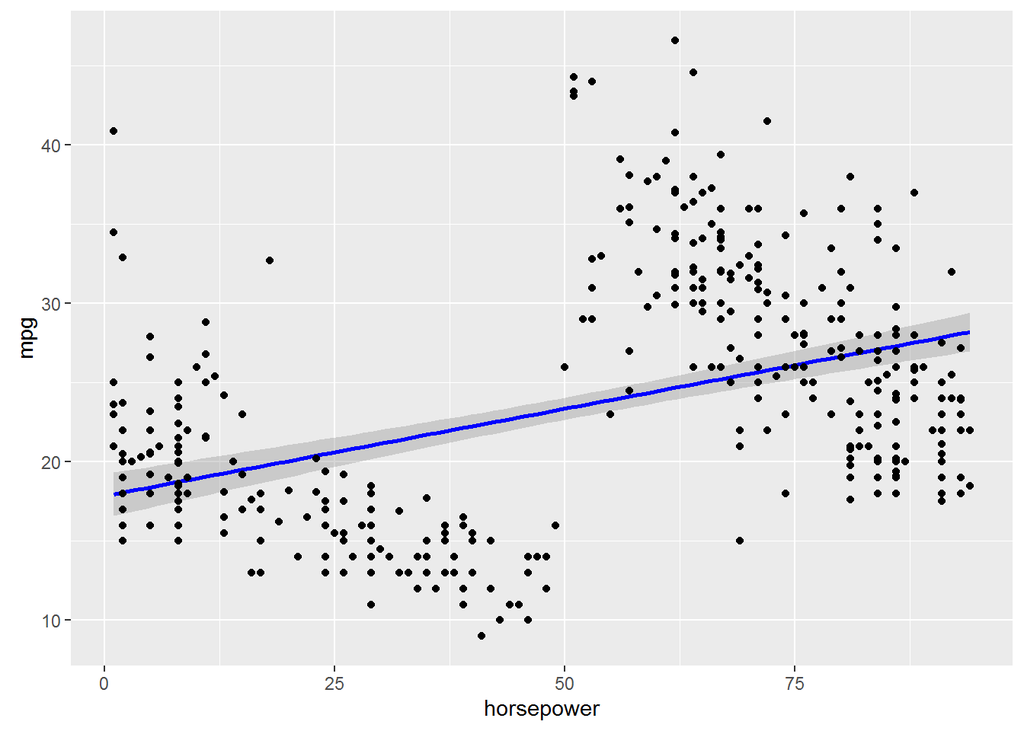

```r
ggplot(mpg_df, aes(y=mpg, x=horsepower)) + geom_smooth(method = "lm", color="blue", formula = y ~ x) + geom_point()
```

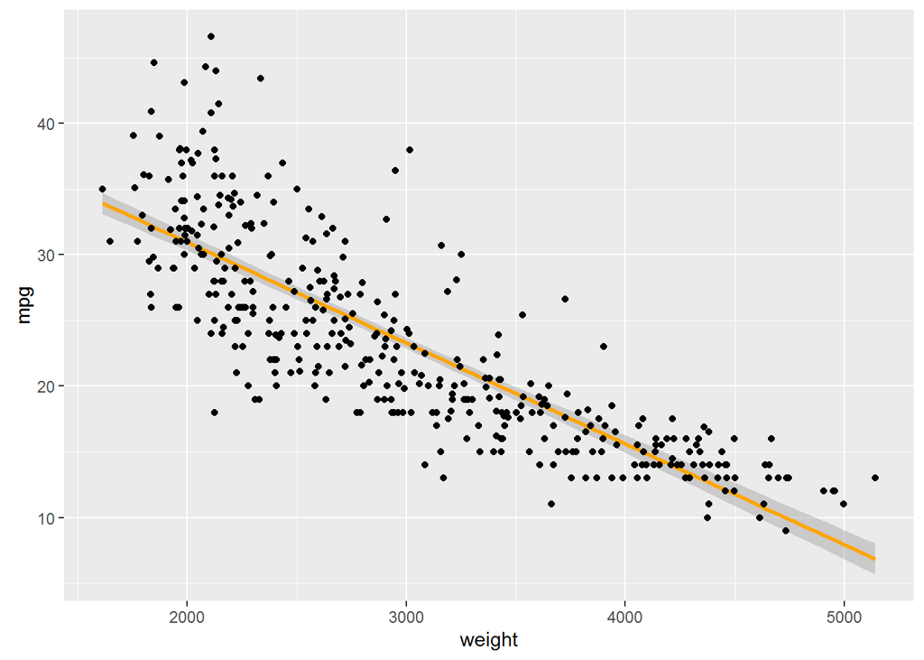

```r
ggplot(mpg_df, aes(y=mpg, x=weight)) + geom_smooth(method = "lm", color="orange", formula = y ~ x) + geom_point()
```

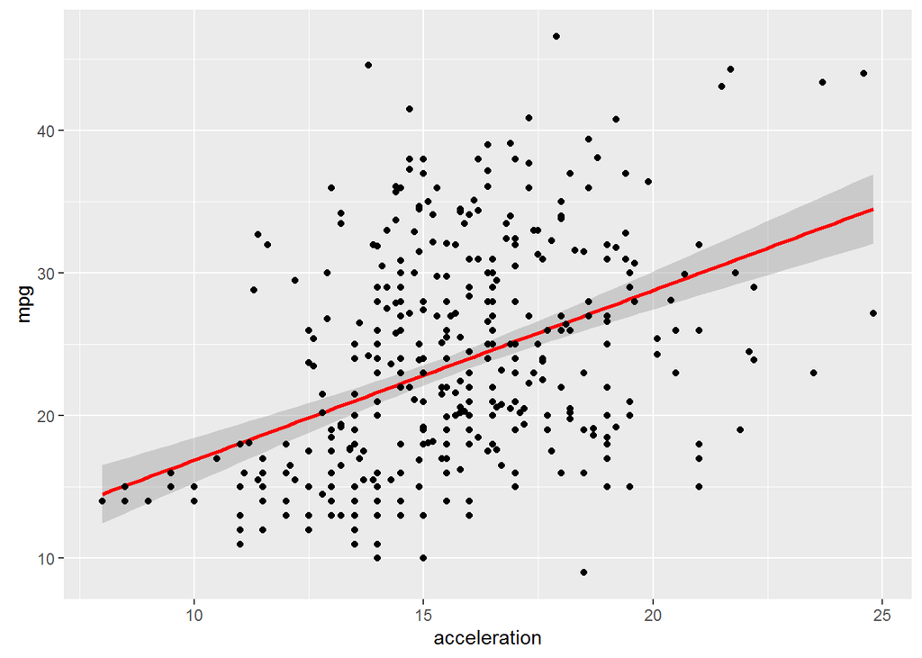

```r
ggplot(mpg_df, aes(y=mpg, x=acceleration)) + geom_smooth(method = "lm", color="red", formula = y ~ x) + geom_point()
```

# TEST

from: http://www.statmethods.net/stats/regression.html

```r
fit <- lm(mpg ~ displacement + horsepower + weight + acceleration, data=mpg_df)
summary(fit) # show results
```

```
##
## Call:
## lm(formula = mpg ~ displacement + horsepower + weight + acceleration,
##     data = mpg_df)
##
## Residuals:
##      Min       1Q   Median       3Q      Max
## -11.8331  -2.8735  -0.3164   2.4449  16.2079
##
## Coefficients:
##                Estimate Std. Error t value Pr(>|t|)
## (Intercept)  40.8838025  1.9966258  20.476  < 2e-16 ***
## displacement -0.0106291  0.0065254  -1.629   0.1041
## horsepower    0.0047774  0.0082597   0.578   0.5633
## weight       -0.0061405  0.0007449  -8.243 2.54e-15 ***
## acceleration  0.1722165  0.0976340   1.764   0.0785 .
## ---
## Signif. codes:  0 '***' 0.001 '**' 0.01 '*' 0.05 '.' 0.1 ' ' 1
##
## Residual standard error: 4.298 on 393 degrees of freedom
## Multiple R-squared:  0.7006, Adjusted R-squared:  0.6976
## F-statistic:   230 on 4 and 393 DF,  p-value: < 2.2e-16
```

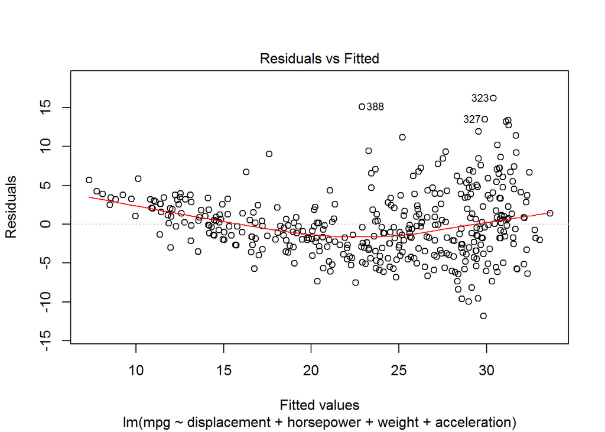

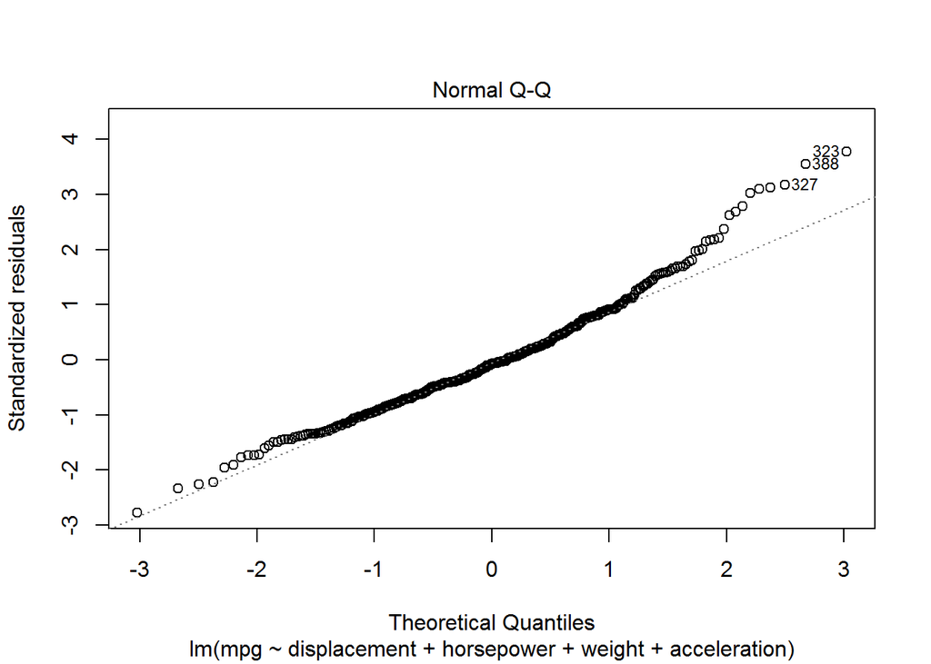

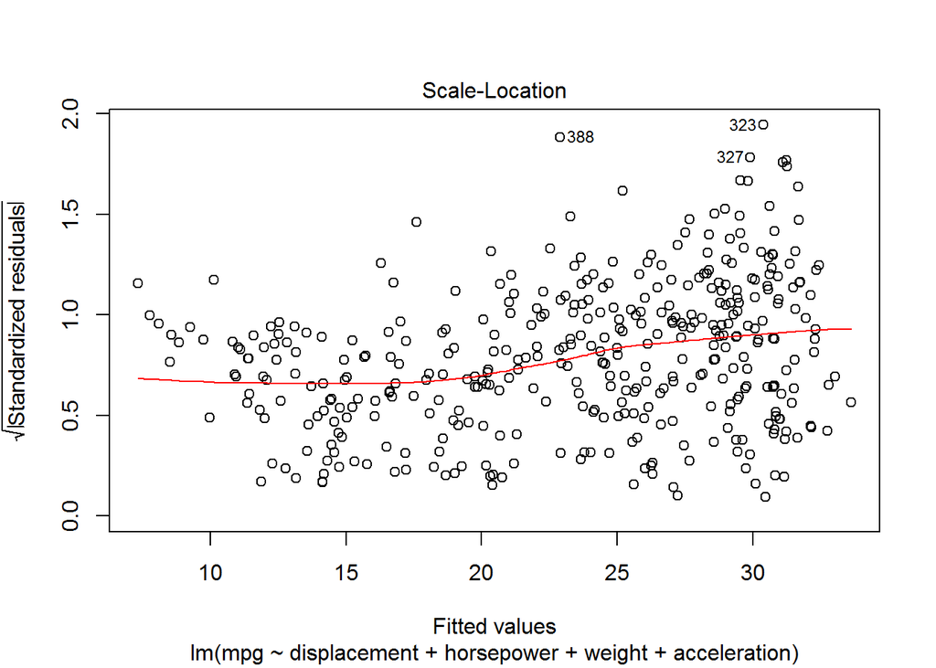

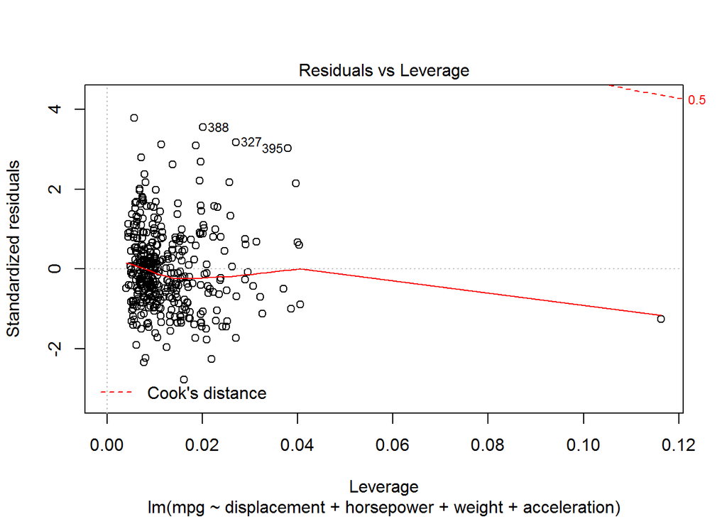

```r
plot(fit)
```

```r
# Other useful functions
#coefficients(fit) # model coefficients
#confint(fit, level=0.95) # CIs for model parameters
#fitted(fit) # predicted values
#residuals(fit) # residuals
#anova(fit) # anova table
#vcov(fit) # covariance matrix for model parameters
#influence(fit) # regression diagnostics
```